# Errores estadísticos habituales en investigación

10 de enero de 2023

## Índice

- Intervalos de confianza
- Contrastes no paramétricos
- Error tipo I vs II
- Interpretación de las pruebas diagnósticas
- Estudios aleatorizados
- *Multiple testing*
- Efecto placebo y grupo control

## Intervalos de confianza

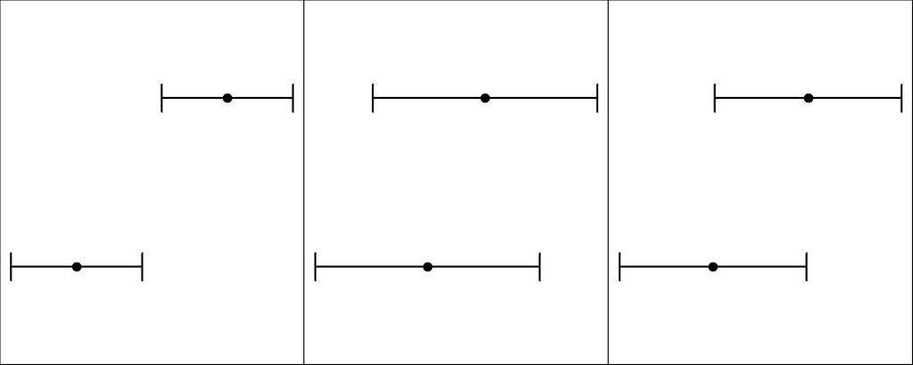

**Criterio 1**: Rechazar la hipótesis de igualdad de efectos si la estimación puntual no de un grupo está incluido en el intervalo del otro grupo.

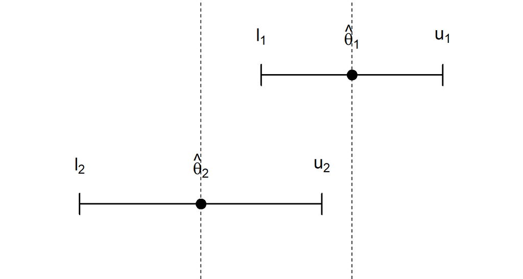

Así, se acepta la igualdad de efectos en las siguientes situaciones:

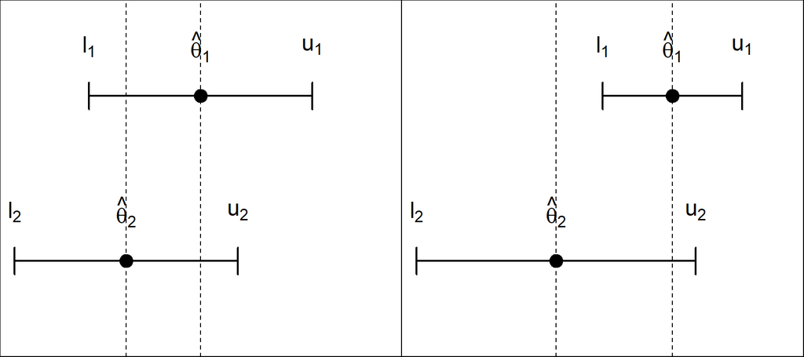

**Criterio 2**: Rechazar la hipótesis de igualdad de efectos si los intervalos no se solapan

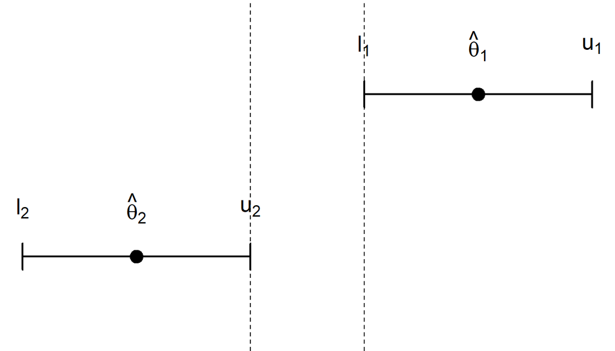

## Fórmulas del test

**Criterio 1**: \(\qquad\) \(Z_1 = \dfrac{\hat{\theta}_1 - \hat{\theta}_2}{\text{max} \{\hat{\sigma}_1, \hat{\sigma}_2\}}\)

**Criterio 2**: \(\qquad\) \(Z_2 = \dfrac{\hat{\theta}_1 - \hat{\theta}_2}{\hat{\sigma}_1 + \hat{\sigma}_2}\)

**Estadístico Z**: \(\qquad\) \(Z = \dfrac{\hat{\theta}_1 - \hat{\theta}_2}{\sqrt{\hat{\sigma}^2_1 + \hat{\sigma}^2_2}}\)

## Por Pitágoras:

- Si los intervalos no se solapan, con el estadístico Z siempre se rechazará la igualdad.
- Si la estimación de uno está dentro de otro intervalo y viceversa, con el estadístico Z siempre se aceptará igualdad.
- En otro caso, depende del grado de solapamiento.

**Rechazamos la H\(_0\) según el estadístico Z**

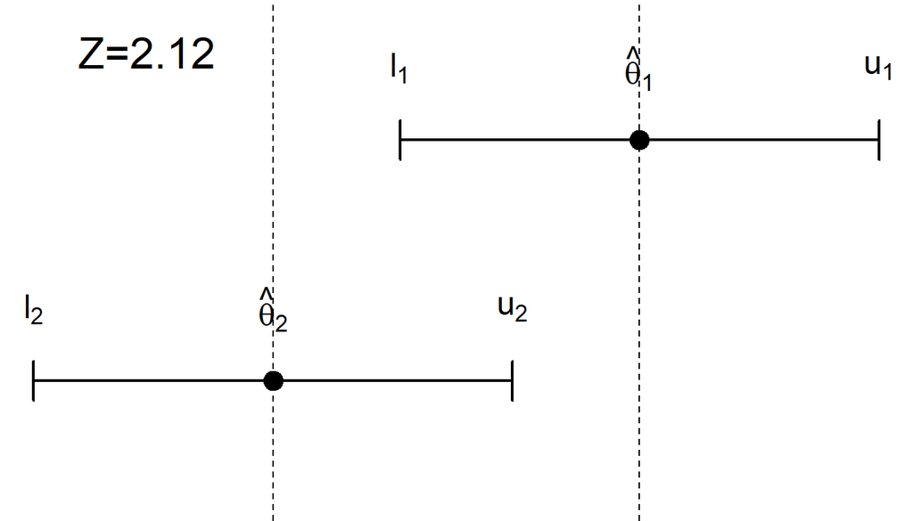

**Aceptamos la H\(_0\) según el estadístico Z**

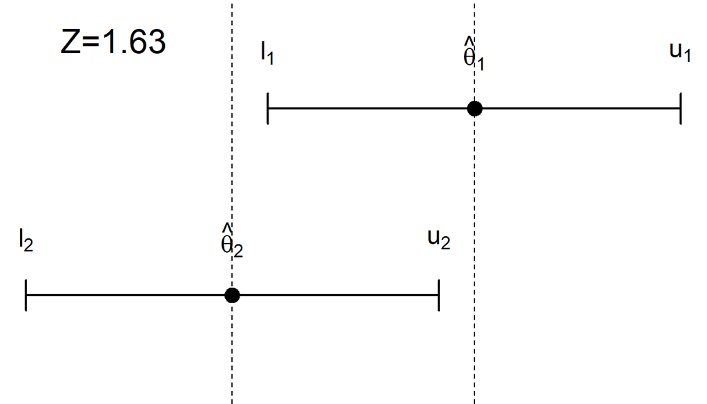

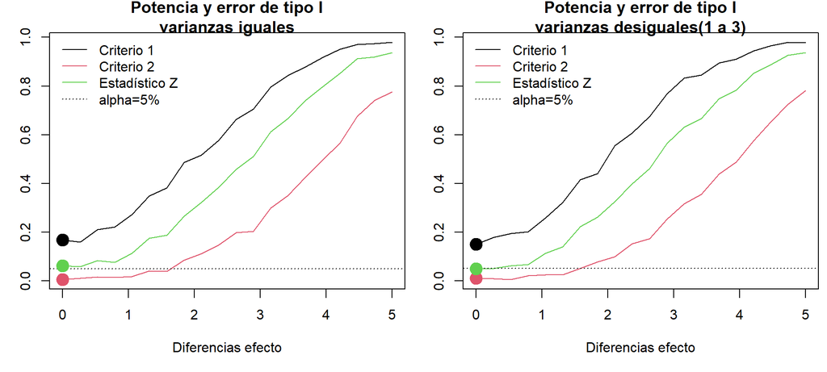

- El criterio 1 da una tasa de falsos positivos (error de tipo I) muy grande (cerca del 20%).
- El criterio 2 da una tasa de falsos positivos muy baja pero a costa de ser muy poco potente.
- Los resultados de potencia son similares tanto si las varianzas entre grupos es la misma o diferente.
- Estos resultados se pueden extrapolar a la comparación de más de dos grupos.
- Este razonamiento se aplica para grupos independientes y no es válido para grupos dependientes o datos apareados.

## Contrastes no paramétricos

- Se usan cuando no se asume o no se sabe la distribución de los datos.
- Son robustos si no se cumplen los criterios de distribución.
- Pero sí asumen algunas condiciones.  
  Por ejemplo, para el test de U de Mann-Whitney: Independencia, **Igualdad de varianzas**, sin o pocos empates.
- Al no asumir una distribución asumen una distribución asimptótica  
  \(\Rightarrow\) **Requieren de un tamaño muestral suficiente**.

## Error tipo I vs II

En el marco de los contrastes de hipótesis:

- Error de tipo I: rechazar la hipótesis nula cuando ésta es cierta.
- Error de tipo II: rechazar la hipótesis alternativa cuando ésta es cierta.

## ¿Cuál es más grave, el error de tipo I o el de tipo II?

- Se fija la probabilidad de error de tipo I = \(\alpha\): nivel de significación (al 5% por ejemplo).
- Una vez fijado \(\alpha\) se puede calcular la probabilidad de error de tipo II que depende del efecto y otros parámetros como la variabilidad, etc.
- Pero a veces es más importante el error de tipo II.
- Verificar las condiciones del modelo: Normalidad, **Igualdad de varianzas**, etc.

## Test de dos medias independientes

- T de Student “ordinaria”: asume varianzas iguales.
- T de Student Welch: no asume varianzas iguales.
- Si las varianzas son diferentes y aceptamos la igualdad de varianzas usaremos una versión incorrecta de la t-Student.
- Si las varianzas son iguales o muy parecidas, el test de la T-Student de Welch es muy parecida a la T-Student ordinaria.
- **\(\Rightarrow\) usar siempre la T-Student de Welch tanto si las varianzas son iguales como si no.**

## Interpretación de las pruebas diagnósticas

- La **sensibilidad** es la proporción de positivos entre los enfermos.
- La **especificidad** es la proporción de negativos entre los sanos.
- El **valor predictivo positivo VPP** es la proporción de enfermos entre los positivos.
- El **valor predictivo negativo VPN** es la proporción de sanos entre los negativos.

## Escenario 1: baja prevalencia

|  | Enfermo | Sano | Total |
| --- | --- | --- | --- |
| Positivo | 80 | 100 | 180 |
| Negativo | 20 | 900 | 920 |
| Total | 100 | 1000 | 1100 |

- Prevalencia de la enfermedad: 100/1100 = 9.1%.
- Sensibilidad: 80/100 = 80%.
- Especificidad: 900/1000 = 90%.
- VPP: 80/180 = 44.4%.
- VPN: 900/920 = 97.8%.

## Escenario 2: alta prevalencia

|  | Enfermo | Sano | Total |
| --- | --- | --- | --- |
| Positivo | 800 | 100 | 900 |
| Negativo | 200 | 900 | 1100 |
| Total | 1000 | 1000 | 2000 |

- Prevalencia de la enfermedad: 1000/2000 = 50%.
- Sensibilidad: 800/1000 = 80%.
- Especificidad: 900/1000 = 90%.
- Valor predictivo positivo (VPP): 800/900 = 88.9%.
- Valor predictivo negativo (VPN): 900/1100 = 81.8%.

## Consideraciones para las pruebas diagnósticas

- Confusión entre valor predictivo positivo (VPP) y sensibilidad.
- Confusión entre valor predictivo negativo (VPN) y especificidad.
- La sensibilidad y la especificidad **no** dependen de la incidencia/prevalencia de la enfermedad.
- El VPP y el VPN **sí** dependen de la incidencia/prevalencia de la enfermedad.
- A nivel individual tiene sentido mirar el VPP y el VPN.
- A nivel poblacional (administración) tiene más sentido mirar la sensibilidad y la especificidad.
- El VPP es alto cuando la prevalencia es alta.
- El VPN es alto cuando la prevalencia es baja.
- En el contexto de la COVID, el índice a mirar es el VPN (probabilidad de no estar infectado si el test da negativo).
- Si no se hacen tests porque el VPP y/o el VPN es bajo, luego la sensbilidad y/o la especificidad son nulos.

## Estudios aleatorizados

- Asignación aleatoria de los tratamientos a los participantes del estudio.
- Si es correcta, las características entre los grupos deberían ser similares.
- Un artículo de *Carlisle et al* comprobó la correcta aleatorización de los ensayos publicados en revistas de alto impacto.
- Para ello, *Carlisle et al* se fijó en cuántas variables presentaban diferencias significativas en la tabla descriptiva según grupo de tratamiento (tabla 1).

Carlisle JB. Data fabrication and other reasons for non-random sampling in 5087 randomised, controlled trials in anaesthetic and general medical journals. Anaesthesia. 2017 Aug;72(8):944-952. doi: 10.1111/anae.13938.

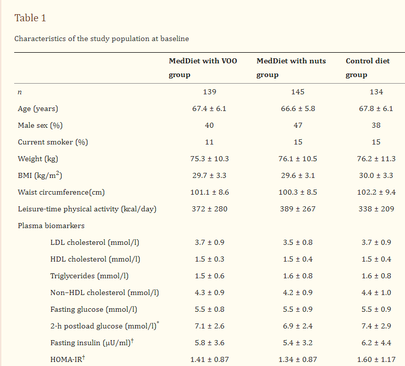

- Premisa que usó *Carlisle et al*: si aprox el 5% de las variables presentaban diferencias significativas, el estudio está bien aleatorizado.
- El artículo causó un gran impacto y muchos de los artículos analizados se tuvieran que revisar.
- **El criterio era erróneo por varios motivos, entre ellos, no consideró que las variables que se describían en la tabla en cada estudio no eran independientes**

## *Multiple testing*

- Cuando se hacen muchos contrastes, por error pueden salir algunos significativos (**Falsos positivos**).
- Considerando un nivel de significación del 5%, de cada 100 contrastes sin efecto, en promedio van a salir 5 significativos.
- \(\Rightarrow\) Corrección de Bonferroni: poner un nivel de significación de acuerdo con el número de contrastes: \(\dfrac{\alpha}{K}\).

## Ejemplo de variantes genéticas

- En un estudio se analizan 1000 SNPs.
- Por motivos técnicos solo se tienen datos de 100 SNPs, por lo que se fija una \(\alpha\) = 0.05/100 = 0.0005.
- Hay 2 SNPs que tienen un p-valor < 0.05/100, concretamente, 0.0003, 0.0002.
- Luego, el data manager consigue recuperar el resto de SNPs y se reanalizan los datos, ahora con un \(\alpha\) = 0.05/1000 = 0.00005.
- Con este “nuevo” nivel de significación, los dos SNPs que antes salían significativos ahora no lo son.
- **¿Qué está pasando? ¿És ésto una contradicción?**

## Efecto placebo y grupo control

## Ejemplo 1: efecto de un tratamiento para perder peso

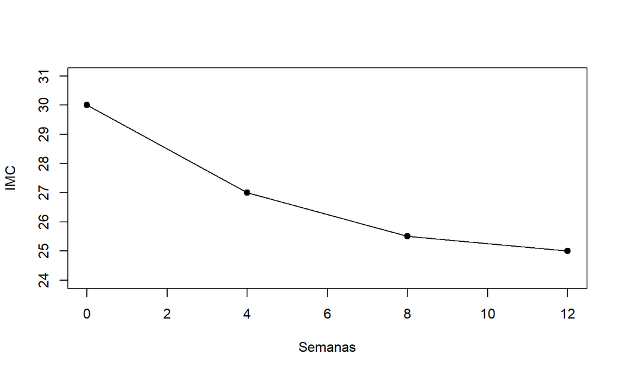

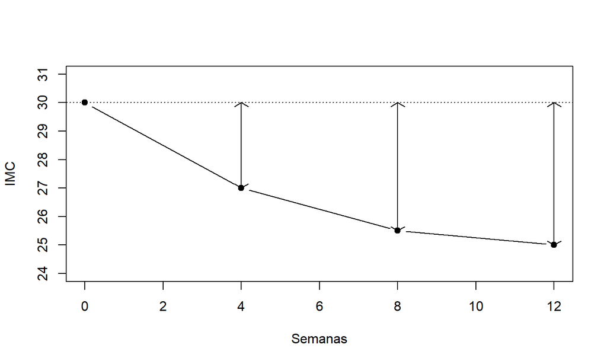

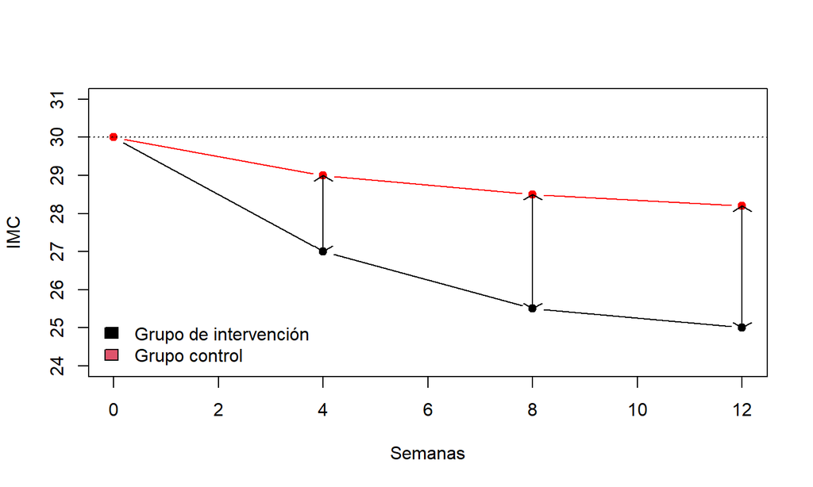

## Ejemplo 2: efecto de la intervención sobre la incidencia de eventos cardiovasculares

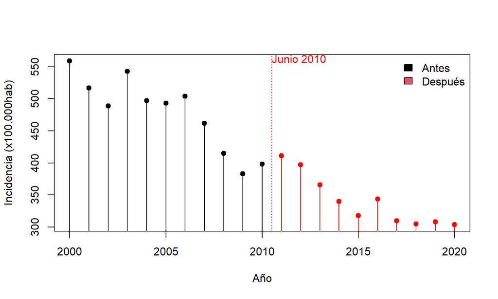

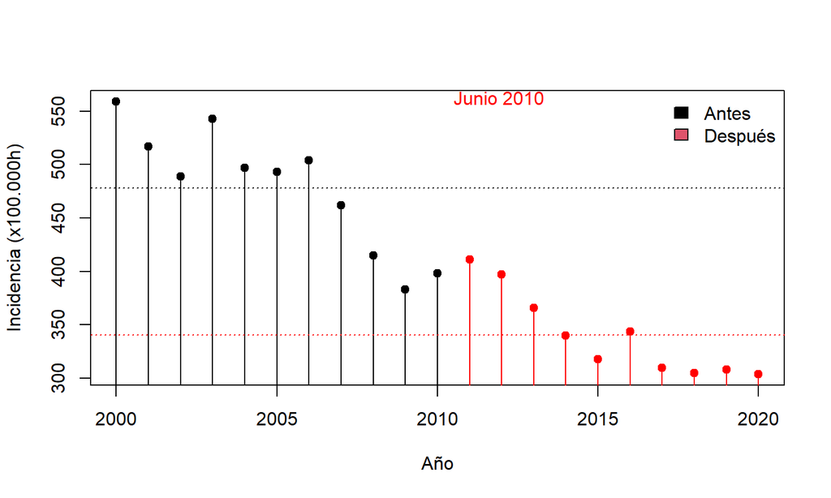

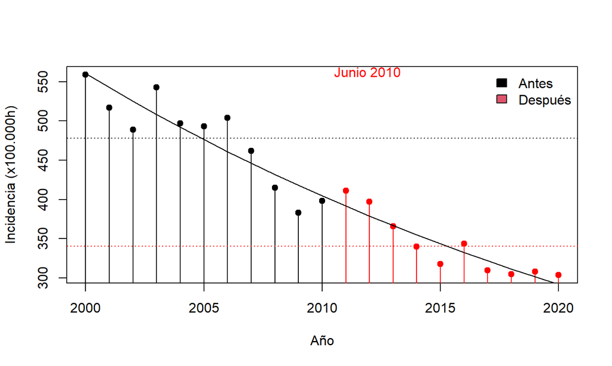

## Ejemplo 3: COVID persistente en niños

[figure not shown]

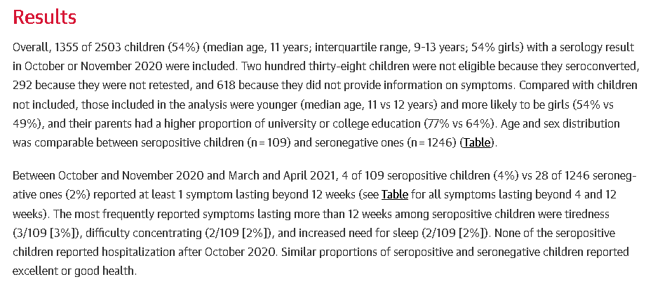

Radtke T, Ulyte A, Puhan MA, Kriemler S. Long-term Symptoms After SARS-CoV-2 Infection in Children and Adolescents. JAMA. 2021;326(9):869–871. doi:10.1001/jama.2021.11880

[figure not shown]

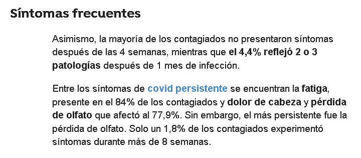

[noticia en la web](https://www.antena3.com/noticias/sociedad/44-ninos-5-17-tienen-covid-persistente-sintomas-como-fatiga-dolor-cabeza-perdida-olfato_20210804610ab0635e57db0001de79e2.html)

- Grupo de infectados y de no infectados (control).
- Las mismas preguntas a los dos grupos.
- Diagnóstico retrospectivo.
- Algunos niños no sabían que habían pasado el COVID (**efecto “nocebo”**).
- La prevalencia observada en el grupo de infectados fue del 4%, y el grupo de no infectados del 2%.  
  \(\Rightarrow\) El efecto neto es del 2% y no resultó estadísticamente significativo.
- El titular del noticiario de A3 reportó sólo la incidencia en un grupo de infectados.